# Métodos Cuantitativos en Ecología - MCE5

#### Unión datos bioclimáticos y modelo glm

```r
tble = rbind(occr, back)

# GLM Model
bioc = stack(bioc)
tble = as.data.frame(tble)

srdf = modelling(algorithm = "GLM", Env = bioc, Occurrences = tble, Pcol = "pb",
                 Xcol = "x", cv.parm = c(0.75, 0.25),
                 Ycol = "y", metric = "TSS", select.metric = "AUC")
```

```
## Data check ...
##    done.
##
## Model evaluation...
##    done.
##
## Model projection...
##    done.
##
## Model axes contribution evaluation...
##    done.
```

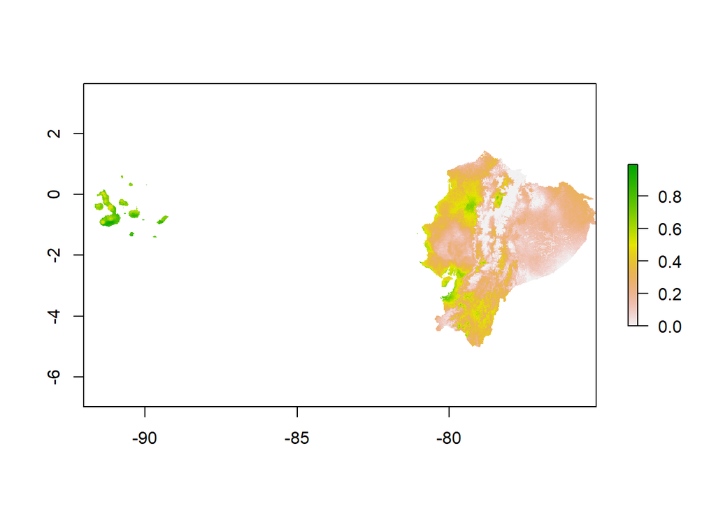

```r
plot(srdf@projection)
```

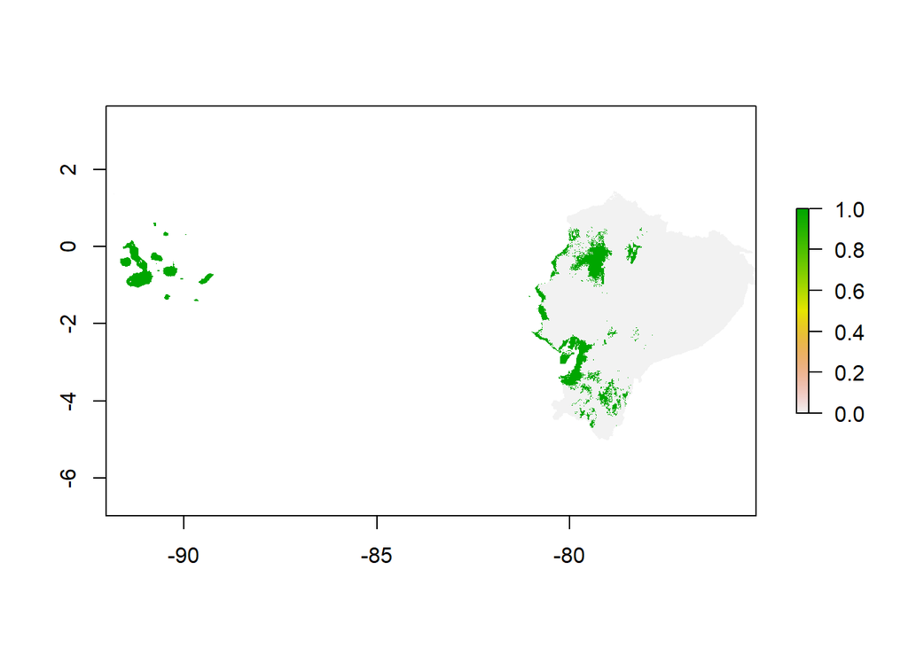

```r
plot(srdf@binary)
```

```r
srdf@parameters
```

```
##                        data metric      cv cv.param axes.metric
## 1 presence/absence data set    TSS holdout   |0.7|2     Pearson
```

```r
srdf@name
```

```
## [1] "GLM.SDM"
```

```r
srdf@variable.importance
```

```
##                    bioc1    bioc2    bioc3   bioc4     bioc5     bioc6
## Axes.evaluation 45.72187 1.477232 3.264571 3.94222 0.1035835 0.1035797
##                     bioc7    bioc8    bioc9  bioc10   bioc11    bioc12 bioc13
## Axes.evaluation 0.1035831 12.43198 0.455499 1.30118 10.45924 0.2148271 1.0053
##                   bioc14      bioc15    bioc16   bioc17   bioc18   bioc19
## Axes.evaluation 5.125226 0.007060997 0.3728563 6.250664 2.046452 5.613075
```

```r
as.numeric(srdf@variable.importance) %>% sum()
```

```
## [1] 100
```

```r
rstr = srdf@projection
rstr = terra::rast(rstr)
rslt = terra::as.data.frame(rstr, xy = T) %>%  as_tibble()

# Built the map
gmap = ggplot() +
  geom_tile(data = rslt, aes(x = x, y = y, fill = Projection)) +
  scale_fill_gradientn(colors = cpt(pal = "mpl_inferno", n=10, rev = TRUE)) +
  geom_sf(data = wrld, fill = NA, col = "grey40", lwd=0.1) +
  geom_sf(data = st_as_sf(ecu1), fill = NA, col = "grey40", lwd=0.3) +
  coord_sf(xlim = ext(ecu1)[1:2], ylim = ext(ecu1)[3:4]) +
  labs(x = "Longitud", y = "Latitud", fill = "Puntaje de Idoneidad") +
  ggtitle(label = "Idoneidad para habitat Passiflore en Ecuador", subtitle = "Modelo GLM") +
  theme_bw() +
  theme(text = element_text(family="georg", color = "grey50"),
        legend.position = "bottom",
        plot.title = element_text(hjust = 0.5, face = "bold", color ="grey30"),
        plot.subtitle = element_text(hjust = 0.5, face = "bold", color ="grey30"),
        panel.border = element_rect(color = "grey80") ) +
  guides(fill = guide_legend(
    direction = "horizontal",
    keyheight = unit(1.15, units = "mm"), keywidth = unit(1.15, units = "mm"),
    title.position = "top", title.hjust = 0.5, label.hjust = 0.5,
    nrow = 1, byrow = T, reverse = F, label.position = "bottom")) +
  annotation_scale(location="bl", width_hint =0.5, text_family = "georg",
                   text_col = "grey60", text_cex = 0.7 ) +
  annotation_north_arrow(
    location= "tr", which_north = "true",
    pad_x = unit(0.1, "in"), pad_y = unit(0.2, "in"),
    style = north_arrow_fancy_orienteering(text_family = "georg", text_col = "grey40"))
```

La proyección para Passiflora es de 0.8 en las provincias de Guayas y ciertas zonas de Galápagos. Con 0.6 las demás zonas de Galápagos, Manabí, Esmeraldas , Zamora y Azuay. En estas zons en donde su idoneidas según el modelo es de 1.

#### Modelo GAM

```r
# GLM Model
bioc = stack(bioc)
tble = as.data.frame(tble)

srdf = modelling(algorithm = "GAM", Env = bioc, Occurrences = tble, Pcol = "pb",
                 Xcol = "x", cv.parm = c(0.75, 0.25),
                 Ycol = "y", metric = "TSS", select.metric = "AUC")
```

```
## Data check ...
##    done.
##
## Model evaluation...
##    done.
##
## Model projection...
##    done.
##
## Model axes contribution evaluation...
##    done.
```

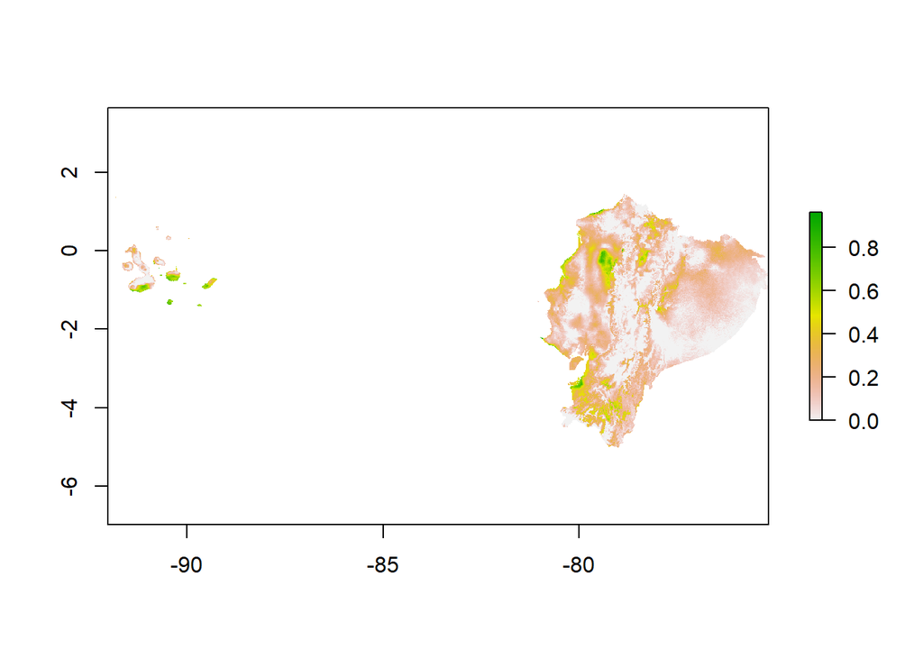

```r
plot(srdf@projection)
```

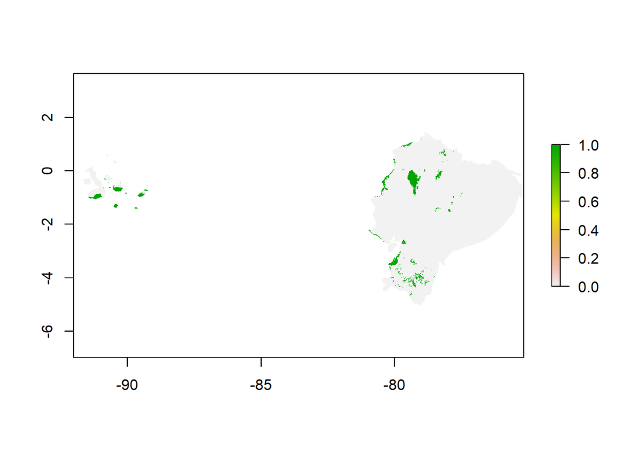

```r
plot(srdf@binary)
```

```r
srdf@parameters
```

```
##                        data metric      cv cv.param axes.metric
## 1 presence/absence data set    TSS holdout   |0.7|2     Pearson
```

```r
srdf@name
```

```
## [1] "GAM.SDM"
```

```r
srdf@variable.importance
```

```
##                    bioc1    bioc2    bioc3    bioc4               bioc5
## Axes.evaluation 5.929617 6.094108 13.89199 11.73585 0.00000000001460512
##                      bioc6    bioc7    bioc8      bioc9      bioc10    bioc11
## Axes.evaluation 0.09864743 11.00305 7.018538 0.05312845 0.008888812 0.8323531
##                   bioc12   bioc13   bioc14     bioc15   bioc16   bioc17
## Axes.evaluation 4.796617 11.73456 1.451001 0.02272584 20.14496 2.444612
##                   bioc18    bioc19
## Axes.evaluation 1.853422 0.8859147
```

```r
as.numeric(srdf@variable.importance) %>% sum()
```

```
## [1] 100
```

```r
rstr = srdf@projection
rstr = terra::rast(rstr)
rslt = terra::as.data.frame(rstr, xy = T) %>%  as_tibble()

# Built the map
gmap1 = ggplot() +
  geom_tile(data = rslt, aes(x = x, y = y, fill = Projection)) +
  scale_fill_gradientn(colors = cpt(pal = "mpl_inferno", n=10, rev = TRUE)) +
  geom_sf(data = wrld, fill = NA, col = "grey40", lwd=0.1) +
  geom_sf(data = st_as_sf(ecu1), fill = NA, col = "grey40", lwd=0.3) +
  coord_sf(xlim = ext(ecu1)[1:2], ylim = ext(ecu1)[3:4]) +
  labs(x = "Longitud", y = "Latitud", fill = "Puntaje de Idoneidad") +
  ggtitle(label = "Idoneidad de hábitat de Passiflora en Ecuador", subtitle = "Modelo GAM") +
  theme_bw() +
  theme(text = element_text(family="georg", color = "grey50"),
        legend.position = "bottom",
        plot.title = element_text(hjust = 0.5, face = "bold", color ="grey30"),
        plot.subtitle = element_text(hjust = 0.5, face = "bold", color ="grey30"),
        panel.border = element_rect(color = "grey80") ) +
  guides(fill = guide_legend(
    direction = "horizontal",
    keyheight = unit(1.15, units = "mm"), keywidth = unit(1.15, units = "mm"),
    title.position = "top", title.hjust = 0.5, label.hjust = 0.5,
    nrow = 1, byrow = T, reverse = F, label.position = "bottom")) +
  annotation_scale(location="bl", width_hint =0.5, text_family = "georg",
                   text_col = "grey60", text_cex = 0.7 ) +
  annotation_north_arrow(
    location= "tr", which_north = "true",
    pad_x = unit(0.1, "in"), pad_y = unit(0.2, "in"),
    style = north_arrow_fancy_orienteering(text_family = "georg", text_col = "grey40"))
```

La proyección para este modelo es de 0.5 para la ocurrencia de Passiflora, se ubica en las ciertas zonas de las provincias de Guayas, Galápagos, Azuay, Zamora, Manabí , Santo Domingo y Pichincha. Su idoneidad es de 1 en las provincias de Guayas, Galápagos, Esmeraldas, Azuay, Zamora, Napo, Santo Domingo y Pihchincha.